# Using Dewey Data for The First Time

Author

Affiliation

David Hansen, Taein Oh, Myungwon Lee, Enmanual De los Santos

Department of Data Science, BYU–Idaho

Published

December 11, 2025

## 1 Abstract

This report is to serve as a simple walkthrough on how to use the Dewey Data platform to access data and to transform that data into an analysis ready format.

## 2 Accessing Data

**Using Dewey Data Platform**

Once you have obtained access to dewey data you can start pulling data immediately. First Navigate to the projects folder within dewey data.

[figure not shown]

Then create a new project with the project button in the top right.

Once the project has been created click on the add datasets. This will bring you to the data set browser. Once you have decided on the data that you are going to use. Use the get data button on in the top right.

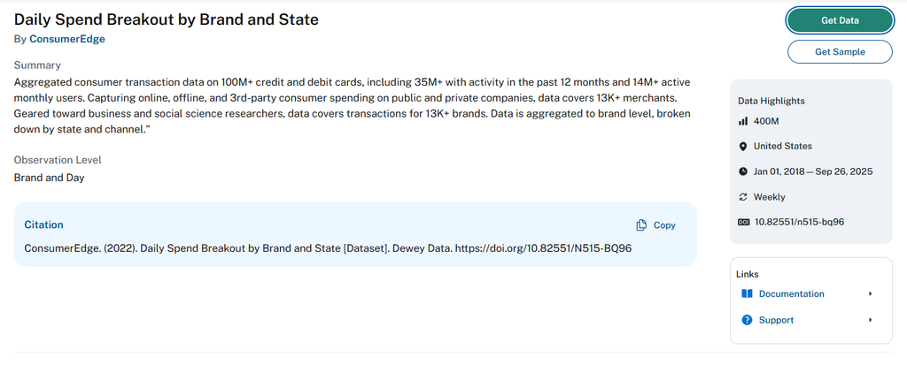

This will bring up a menu that will allow you to add the data set to the project.

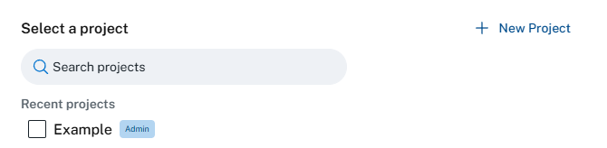

Once you have added the dataset to the project navigate back to the project page. You should now see a dataset available.

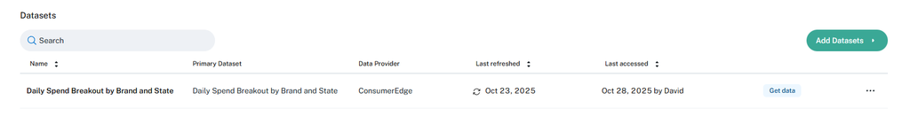

Use the get data button. This will bring you to the data preview and fitlering options.

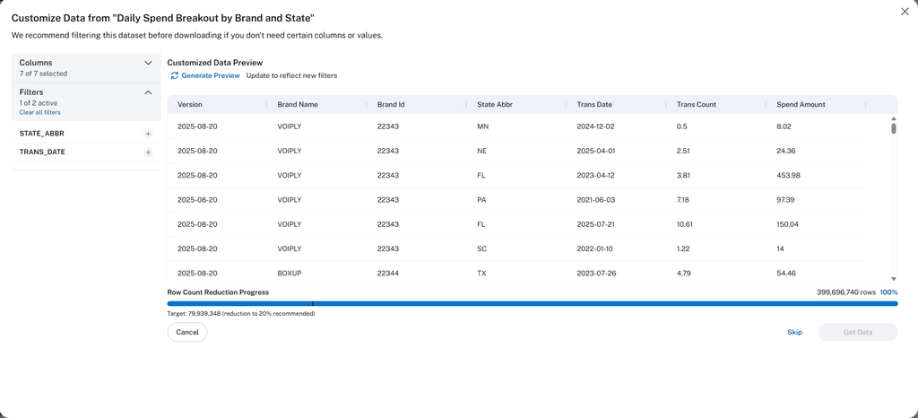

**Please review the data size.** These data sets can be very large and is recommended that you use the filters to reduce large datasets to 20% of the original size.

Once you have filtered the dataset to your prefered data down below 20% the get data button on the bottom right will become usable. This will let you select the file type, either csv or parquet and will begin your download.

**Using Bulk API**

If you require the entire data set you can use the skip button to access the bulk API to download entire sets. It will bring you to a menu with a size overview and a bulk API dropdown option.

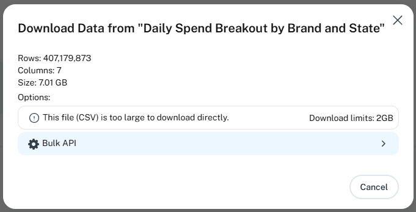

Once you open this dropdown menu it will show you the API key to access the data. **This API key is only shown once.** Save it in a secure location. Never share your API Key.

To use the bulk API it is recommended that you use the CLI tool to download the data. A simple walk through for using the CLI tool can be found [here](https://docs.deweydata.io/docs/dewey-client).

## 3 From Raw Files to Data Frame

Once your files have downloaded, you should see them inside your dewey-downloads folder. Depending on how you pulled the data, these will either be zipped CSV files (.csv.gz) or Parquet files (.parquet). You can load individual files to inspect them, but it’s often easier to combine everything into one unified dataset.

### 3.1 Code Examples

**With Pandas**

A great tool to do this is with the Pandas package.

```python
import pandas as pd
from pathlib import Path

# ---------------------------------------------
# 1. Define your folders
# ---------------------------------------------
download_location = Path("path/to/dewey-downloads")
target_dir = Path("path/to/save/final/file")

# ---------------------------------------------
# 2. Get a list of files
# ---------------------------------------------
# For zipped CSVs:
list_file_names = sorted(download_location.glob("*.csv.gz"))

# For Parquet:
# list_file_names = sorted(download_location.glob("*.parquet"))

# ---------------------------------------------
# 3. Read and combine all files using Pandas
# ---------------------------------------------
# Read each file into a pandas DataFrame
df_list = []

for f in list_file_names:
    if f.suffix == ".gz" or f.suffixes[-1] == ".gz":
        df = pd.read_csv(f)
    elif f.suffix == ".parquet":
        df = pd.read_parquet(f)
    else:
        continue
    df_list.append(df)

# Concatenate all files into one table
all_files_combined = pd.concat(df_list, ignore_index=True)

# ---------------------------------------------
# 4. Save your final dataset
# ---------------------------------------------
output_path_csv = target_dir / "combined_data.csv"
output_path_parquet = target_dir / "combined_data.parquet"

# For CSV:
all_files_combined.to_csv(output_path_csv, index=False)

# For Parquet:
all_files_combined.to_parquet(output_path_parquet, index=False)
```

**With Polars**

Alternatively we can use Polars, which is typically faster than pandas when working with larger datasets.

```python
import polars as pl
from pathlib import Path

# ---------------------------------------------
# 1. Define your folders
# ---------------------------------------------
download_location = Path("path/to/dewey-downloads")
target_dir = Path("path/to/save/final/file")

# ---------------------------------------------
# 2. Get a list of files
# ---------------------------------------------
# For zipped Csv's:
list_file_names = sorted(download_location.glob("*.csv.gz"))

# For Parquet:
list_file_names = sorted(download_location.glob("*.parquet"))

# ---------------------------------------------
# 3. Read and combine all files using Polars Lazy (efficient)
# ---------------------------------------------
lazy_frames = [pl.scan_csv(f) for f in list_file_names]   # or scan_parquet(f)
lf = pl.concat(lazy_frames, how="vertical_relaxed")

# Collect into a single DataFrame
all_files_combined = lf.collect(streaming=True)

# ---------------------------------------------
# 4. Save your final dataset
# ---------------------------------------------
output_path_csv = target_dir / "combined_data.csv"
output_path_parquet = target_dir / "combined_data.parquet"

# For Csv:
all_files_combined.write_csv(output_path_csv)

# For Parquet:
all_files_combined.write_parquet(output_path_parquet)
```

Now all the individual files should be combined in one dataset. Once individual files are unified we can use any analysis tool to method to pull vaulable insights